# week 3 - stock market analysis

Huizhe (Sunny) Zhu - hz2657

9/23/2020

## Part 1: Import stock datasets for Amazon (AMZN), FaceBook (FB), Google (GOOGL)

```r
# import libraries
library(quantmod)
library(TTR)
library(tidyverse) # https://www.tidyverse.org/
library(dplyr) # or just dplyr
library(PerformanceAnalytics)
```

### 1.1 get the datasets

- we will choose the stock of Amazon (AMZN), FaceBook (FB), Google (GOOGL) to analyze.

```r
# download the historical data of a symbol
getSymbols(c("AMZN","LMT","AAPL","FB","GOOGL"))
```

```
## [1] "AMZN"  "LMT"   "AAPL"  "FB"    "GOOGL"
```

```r
# getSymbols uses the symbol name as the dataset name
```

### 1.2 EDA on stock dataset

For Amazon stock dataset, it contains stock information from 2007-01-03 to today (2020-09-25), which is 3458 days’ information

```r
head(AMZN)
```

```
##            AMZN.Open AMZN.High AMZN.Low AMZN.Close AMZN.Volume AMZN.Adjusted
## 2007-01-03     38.68     39.06    38.05      38.70    12405100         38.70
## 2007-01-04     38.59     39.14    38.26      38.90     6318400         38.90
## 2007-01-05     38.72     38.79    37.60      38.37     6619700         38.37
## 2007-01-08     38.22     38.31    37.17      37.50     6783000         37.50
## 2007-01-09     37.60     38.06    37.34      37.78     5703000         37.78
## 2007-01-10     37.49     37.70    37.07      37.15     6527500         37.15
```

```r
dim(AMZN)
```

```
## [1] 3458    6
```

```r
summary(AMZN)
```

```
##      Index              AMZN.Open         AMZN.High          AMZN.Low
##  Min.   :2007-01-03   Min.   :  35.29   Min.   :  37.07   Min.   :  34.68
##  1st Qu.:2010-06-09   1st Qu.: 131.28   1st Qu.: 133.02   1st Qu.: 129.77
##  Median :2013-11-12   Median : 304.37   Median : 307.73   Median : 301.51
##  Mean   :2013-11-13   Mean   : 642.69   Mean   : 649.64   Mean   : 634.97
##  3rd Qu.:2017-04-20   3rd Qu.: 908.47   3rd Qu.: 911.05   3rd Qu.: 902.45
##  Max.   :2020-09-25   Max.   :3547.00   Max.   :3552.25   Max.   :3486.69
##    AMZN.Close       AMZN.Volume        AMZN.Adjusted
##  Min.   :  35.03   Min.   :   881300   Min.   :  35.03
##  1st Qu.: 131.51   1st Qu.:  3091675   1st Qu.: 131.51
##  Median : 305.06   Median :  4503950   Median : 305.06
##  Mean   : 642.69   Mean   :  5626996   Mean   : 642.69
##  3rd Qu.: 907.32   3rd Qu.:  6769200   3rd Qu.: 907.32
##  Max.   :3531.45   Max.   :104329200   Max.   :3531.45
```

For FB stock dataset, it contains stock information from 2012-05-18 to today (2020-09-25), which is 2103 days’ information

```r
dim(FB)
```

```
## [1] 2103    6
```

```r
summary(FB)
```

```
##      Index               FB.Open          FB.High           FB.Low
##  Min.   :2012-05-18   Min.   : 18.08   Min.   : 18.27   Min.   : 17.55
##  1st Qu.:2014-06-23   1st Qu.: 68.11   1st Qu.: 69.02   1st Qu.: 67.25
##  Median :2016-07-25   Median :118.62   Median :119.30   Median :117.57
##  Mean   :2016-07-23   Mean   :119.35   Mean   :120.73   Mean   :117.94
##  3rd Qu.:2018-08-23   3rd Qu.:174.09   3rd Qu.:175.80   3rd Qu.:171.95
##  Max.   :2020-09-25   Max.   :300.16   Max.   :304.67   Max.   :293.05
##     FB.Close        FB.Volume          FB.Adjusted
##  Min.   : 17.73   Min.   :  5913100   Min.   : 17.73
##  1st Qu.: 68.33   1st Qu.: 16317650   1st Qu.: 68.33
##  Median :118.57   Median : 23734800   Median :118.57
##  Mean   :119.40   Mean   : 32568252   Mean   :119.40
##  3rd Qu.:173.77   3rd Qu.: 38507650   3rd Qu.:173.77
##  Max.   :303.91   Max.   :573576400   Max.   :303.91
```

For Google stock dataset, it contains stock information from 2007-01-03 to today (2020-09-25), which is 3458 days’ information

```r
head(GOOGL)
```

```
##            GOOGL.Open GOOGL.High GOOGL.Low GOOGL.Close GOOGL.Volume
## 2007-01-03   233.2332   238.5686  230.7858    234.0290     15397500
## 2007-01-04   234.7347   242.2172  234.4094    241.8719     15759400
## 2007-01-05   241.4915   243.9940  239.2943    243.8388     13730400
## 2007-01-08   244.0891   245.1802  241.3413    242.0320      9499200
## 2007-01-09   242.9680   244.3694  240.8408    242.9930     10752000
## 2007-01-10   242.4575   247.0220  241.2613    244.9750     11925000
##            GOOGL.Adjusted
## 2007-01-03       234.0290
## 2007-01-04       241.8719
## 2007-01-05       243.8388
## 2007-01-08       242.0320
## 2007-01-09       242.9930
## 2007-01-10       244.9750
```

```r
dim(GOOGL)
```

```
## [1] 3458    6
```

```r
summary(GOOGL)
```

```
##      Index              GOOGL.Open       GOOGL.High       GOOGL.Low
##  Min.   :2007-01-03   Min.   : 131.4   Min.   : 134.8   Min.   : 123.8
##  1st Qu.:2010-06-09   1st Qu.: 278.9   1st Qu.: 282.6   1st Qu.: 275.0
##  Median :2013-11-12   Median : 510.4   Median : 514.5   Median : 504.4
##  Mean   :2013-11-13   Mean   : 602.9   Mean   : 608.5   Mean   : 596.9
##  3rd Qu.:2017-04-20   3rd Qu.: 870.4   3rd Qu.: 874.2   3rd Qu.: 867.2
##  Max.   :2020-09-25   Max.   :1699.5   Max.   :1726.1   Max.   :1660.2
##   GOOGL.Close      GOOGL.Volume      GOOGL.Adjusted
##  Min.   : 128.8   Min.   :  520600   Min.   : 128.8
##  1st Qu.: 278.8   1st Qu.: 1708525   1st Qu.: 278.8
##  Median : 508.3   Median : 3435100   Median : 508.3
##  Mean   : 602.9   Mean   : 4801596   Mean   : 602.9
##  3rd Qu.: 871.8   3rd Qu.: 6111350   3rd Qu.: 871.8
##  Max.   :1717.4   Max.   :46528000   Max.   :1717.4
```

In this topic, features include **moving average**, which characterizes the movement of a stock price.

Features also include **technical indicators**, such as SMA, RSI, MACD, stochastic oscillators, Bollinger Bands etc.

These features can be fit in machine learning models, or be treated as trading signals

A simple moving average (SMA) calculates the average of a selected range of prices, usually closing prices, by the number of periods in that range. SMA is a technical indicator that can aid in determining if an asset price will continue or if it will reverse a bull or bear trend.

## Part 2: explore 3 strategies on one stock, EDA

We will take Amazon’s stock as example and explain from the graph about each strategy.

The graph below shows Amazon’s 12-PERIOD SMA, 26-PERIOD SMA, Moving average convergence divergence (MACD) and it’s signal, and Relative Strength Index (RSI).

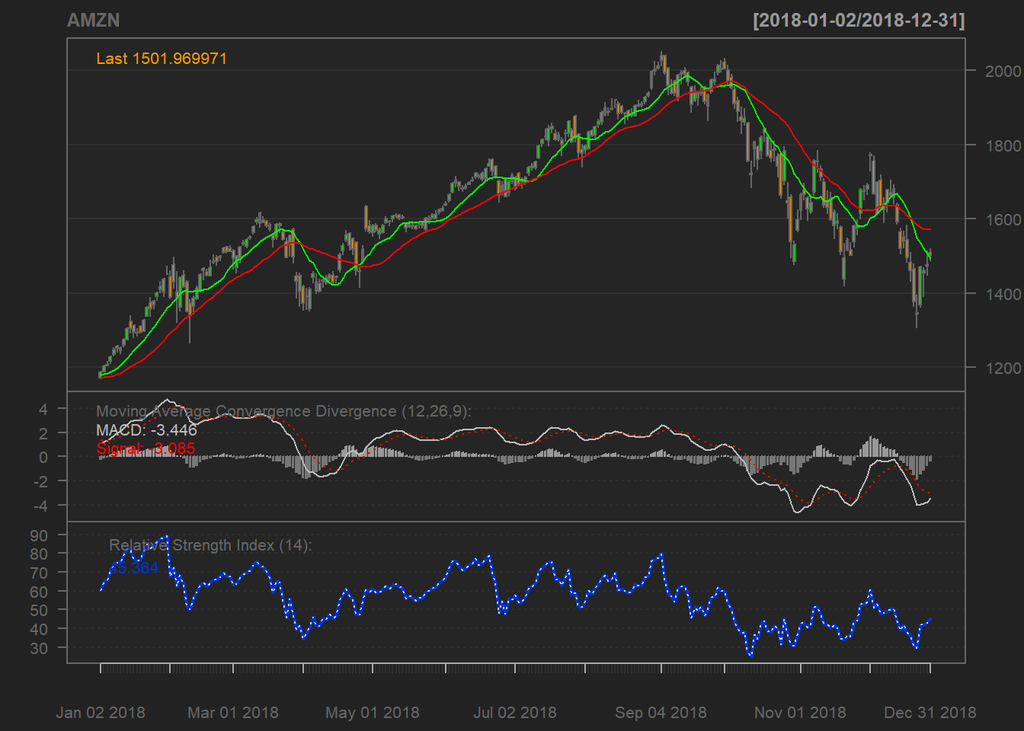

```r
options(repr.plot.width = 6, repr.plot.height = 3)
chartSeries(AMZN, subset = "2018::2018-12",bar.type='hlc',
            TA = c(addSMA(n=12,col="green"),addSMA(n=26,col="red"),
                addMACD(),addRSI()))
```

### 2.1 Strategy 1: Enter and stay in the market when MACD>Signal

**MACD — Moving Average Convergence Divergence**

MACD is the difference between the 12-period simple moving average (SMA) and 26-period simple moving average (MACD = 12-period SMA − 26-period SMA), or “fast SMA — slow SMA”. The reason they are called fast and slow respectively is because the 12-period SMA reacts faster to the more recent price changes, than the 26-period SMA. The strategy is

- If the MACD signal crossed above the signal line then we enter market and stay
- If the MACD signal crossed below the signal line we exit the market

Signial is the moving average of MACD in 9 periods.

### 2.2 Strategy 2: Enter and stay in the market when overbought (RSI>70)

Strategy 2 uses RSI — Relative Strength Index, it suggests enter and stay in the market when overbought. The market is overbought when RSI > 70.

From the graph, when the blue line is above 70, strategy 2 suggests to enter the market.

### 2.3 Strategy 3: Enter and stay in the market when oversold (RSI<30)

Strategy 2 suggests enter and stay in the market when oversold. The market is oversold when RSI < 30.

From the graph, when the blue line is below 30, strategy 3 suggests to enter the market.

### 2.4 Strategy 4: Buy-and-hold: keep it all time. So set all values to “1”

We set strategy equals to 1 all the time

## Part 3: implement strategies, in-sample backtesting, choose the optimal strategy

Backtesting is a critical step before implementing a strategy. It applies a trading strategy to historical data to see how accurately the strategy or method would have predicted. The essential metrics in a backtesting include:

- **cumulative returns** The cumulative return is the total change in the investment price over a set time—an aggregate return, not an annualized one
- **Annualized returns** Annualized returns is the geometric average amount of money earned by an investment each year over a given time period. The annualized return formula is calculated as a geometric average to show what an investor would earn over a period of time if the annual return was compounded
- **Sharpe ratio** It measures the performance of an investment compared to a risk-free asset. It is defined as the difference between the returns of the investment and the risk-free return, divided by the standard deviation of the investment

The higher a fund’s Sharpe ratio, the better a fund’s returns have been relative to the risk it has taken on.

- the annualized Sharpe ratio

```r
# write a function for backtest for strategy 1-3
backtest <- function(df,from_date,to_date,strategy,strategy_name){
    rtn.daily <- dailyReturn(df)
    rtn <- rtn.daily[index(rtn.daily)<=to_date & index(rtn.daily)>=from_date]
    trade_return <- rtn * lag(strategy, na.pad = FALSE)
    cumm_return <- Return.cumulative(trade_return)
    annual_return <- Return.annualized(trade_return)
    summary(as.ts(trade_return))
    SharpeRatio <- SharpeRatio(as.ts(trade_return), Rf = 0, p = 0.95, FUN = "StdDev")
    SharpeRatioAnnualized <- SharpeRatio.annualized(trade_return, Rf = 0)
    out <- as.data.frame(c(cumm_return,annual_return,SharpeRatio,SharpeRatioAnnualized))
    out <- round(out,2)
    colnames(out) <- strategy_name
    row.names(out) <- c('Cumulative Return','Annualized Return',
                 'Sharpe Ratio','Annualized Sharpe Ratio')

  return( out )
    }


# backtest function for Buy-and-hold strategy
BH_backtest <- function(df,from_date,to_date,strategy_name){
    rtn.daily <- dailyReturn(df)
    trade_return <- rtn.daily[index(rtn.daily)<=to_date & index(rtn.daily)>=from_date]
    cumm_return <- Return.cumulative(trade_return)
    annual_return <- Return.annualized(trade_return)
    summary(as.ts(trade_return))
    SharpeRatio <- SharpeRatio(as.ts(trade_return), Rf = 0, p = 0.95, FUN = "StdDev")
    SharpeRatioAnnualized <- SharpeRatio.annualized(trade_return, Rf = 0)
    out <- as.data.frame(c(cumm_return,annual_return,SharpeRatio,SharpeRatioAnnualized))
    out <- round(out,2)
    colnames(out) <- strategy_name
    row.names(out) <- c('Cumulative Return','Annualized Return',
                     'Sharpe Ratio','Annualized Sharpe Ratio')

  return( out )
    }
```

Here We write a function that can return the performance table given the stock name, then we can evaluate which strategy works best for each stock

```r
# performance_table(AMZN, '2012-07-01', '2015-12-31')

performance_table <- function(stock_name, from_date, to_date){


  rsi <- RSI(stock_name[,ncol(stock_name)], n = 14, maType = "SMA")

macd <- MACD(stock_name[,ncol(stock_name)], nFast = 12, nSlow = 26, nSig = 9,
   maType = "SMA", percent = FALSE)


  # Strategy 1
strategy1 <- ifelse ((macd$signal < macd$macd) , 1, 0)
strategy1[is.na(strategy1)] <-0

strategy1_performance <- backtest(stock_name, from_date = from_date,
    to_date = to_date, strategy1,"Strategy1")

# Strategy 2
strategy2 <- ifelse ((macd$signal < macd$macd) & (rsi$rsi > 70), 1, 0)
strategy2[is.na(strategy2)] <-0

strategy2_performance <- backtest(stock_name, from_date = from_date,
    to_date = to_date, strategy2,"Strategy2")

# Strategy 3
strategy3 <- ifelse ((macd$signal > macd$macd) & (rsi$rsi < 30), 1, 0)
strategy3[is.na(strategy3)] <-0

strategy3_performance <- backtest(stock_name, from_date = from_date,
    to_date = to_date, strategy3,"Strategy3")

# Strategy 4:buy_and_hold Strategy
bh_strategy <- rep(1,dim(macd)[1])

buy_and_hold_performance <- BH_backtest(stock_name, from_date = from_date, to_date = to_date,"Buy & Hold Strategy")

final_table  <- cbind(strategy1_performance,strategy2_performance, strategy3_performance, buy_and_hold_performance)

return(final_table)
}
```

### time period: ‘2012-07-01’ to ‘2016-12-31’

#### for Amazon

from the table below, we can see for Amazon stock, from ‘2012-07-01’ to ‘2016-12-31’

- Buy & Hold Strategy gives the best cumulative return and anulized return and sharp ratio

```r
performance_table(AMZN,'2012-07-01', '2016-12-31')
```

```
##                         Strategy1 Strategy2 Strategy3 Buy & Hold Strategy
## Cumulative Return            0.36      0.13      0.17                2.28
## Annualized Return            0.07      0.03      0.04                0.30
## Sharpe Ratio                 0.03      0.02      0.03                0.06
## Annualized Sharpe Ratio      0.33      0.28      0.42                1.00
```

#### for Facebook

from the table below, we can see for Facebook stock, from ‘2012-07-01’ to ‘2016-12-31’

- Buy & Hold Strategy gives the best cumulative return and annulized return and sharp ratio

```r
performance_table(FB,'2012-07-01', '2016-12-31')
```

```
##                         Strategy1 Strategy2 Strategy3 Buy & Hold Strategy
## Cumulative Return            1.16      0.12      0.26                2.70
## Annualized Return            0.19      0.03      0.05                0.34
## Sharpe Ratio                 0.05      0.01      0.02                0.06
## Annualized Sharpe Ratio      0.69      0.14      0.32                0.86
```

#### for Google

from the table below, we can see for Google stock, from ‘2012-07-01’ to ‘2016-12-31’

- Buy and hold strategy gives the best cumulative return, annulized return, and sharp ratio

```r
performance_table(GOOGL,'2012-07-01', '2016-12-31')
```

```
##                         Strategy1 Strategy2 Strategy3 Buy & Hold Strategy
## Cumulative Return            0.57      0.34      0.35                1.73
## Annualized Return            0.11      0.07      0.07                0.25
## Sharpe Ratio                 0.04      0.04      0.06                0.07
## Annualized Sharpe Ratio      0.63      0.67      1.03                1.08
```

## Strategy evaluation: optimal trading rule

- We recommend Buy & Hold Strategy for Amazon’s and Facebook’s stock.
- For Google’s stock, we will keep examine other samples and recommend a strategy in Part 4.

## Part 4: out of sample test for selected strategy

#### for Amazon

```r
performance_table(AMZN,'2017-07-01', '2020-09-01')
```

```
##                         Strategy1 Strategy2 Strategy3 Buy & Hold Strategy
## Cumulative Return            0.78      0.39      0.48                2.61
## Annualized Return            0.20      0.11      0.13                0.50
## Sharpe Ratio                 0.06      0.06      0.07                0.09
## Annualized Sharpe Ratio      0.95      0.90      1.16                1.58
```

#### for Facebook

```r
performance_table(FB,'2017-07-01', '2020-09-01')
```

```
##                         Strategy1 Strategy2 Strategy3 Buy & Hold Strategy
## Cumulative Return           -0.05     -0.10      0.18                0.96
## Annualized Return           -0.02     -0.03      0.05                0.24
## Sharpe Ratio                 0.00     -0.01      0.03                0.05
## Annualized Sharpe Ratio     -0.06     -0.22      0.44                0.66
```

#### for Google

- Buy and hold strategy gives higher cumulative return
- while strategy 3 gives higher sharp ratio

```r
performance_table(GOOGL,'2017-07-01', '2020-09-01')
```

```
##                         Strategy1 Strategy2 Strategy3 Buy & Hold Strategy
## Cumulative Return           -0.15     -0.10      0.34                0.78
## Annualized Return           -0.05     -0.03      0.10                0.20
## Sharpe Ratio                -0.01     -0.02      0.05                0.05
## Annualized Sharpe Ratio     -0.27     -0.37      0.85                0.69
```

### time period: ‘2020-01-01’ to ‘2020-09-01’

Now let’s use the period from ‘2020-01-01’ to ‘2020-09-01’ for testing.

#### for Amazon

```r
performance_table(AMZN,'2020-01-01', '2020-09-01')
```

```
##                         Strategy1 Strategy2 Strategy3 Buy & Hold Strategy
## Cumulative Return            0.67      0.22      0.11                0.89
## Annualized Return            1.16      0.34      0.16                1.59
## Sharpe Ratio                 0.17      0.10      0.07                0.16
## Annualized Sharpe Ratio      3.93      1.70      1.06                4.03
```

#### for Facebook

```r
performance_table(FB,'2020-01-01', '2020-09-01')
```

```
##                         Strategy1 Strategy2 Strategy3 Buy & Hold Strategy
## Cumulative Return            0.26      0.18     -0.03                0.44
## Annualized Return            0.41      0.28     -0.04                0.72
## Sharpe Ratio                 0.09      0.11     -0.01                0.08
## Annualized Sharpe Ratio      1.48      1.87     -0.18                1.46
```

#### for Google

- Buy and hold strategy gives higher cumulative return, while strategy 1 gives higher sharp ratio

```r
performance_table(GOOGL,'2020-01-01', '2020-09-01')
```

```
##                         Strategy1 Strategy2 Strategy3 Buy & Hold Strategy
## Cumulative Return            0.15      0.03      0.01                0.24
## Annualized Return            0.23      0.04      0.01                0.37
## Sharpe Ratio                 0.06      0.03      0.01                0.06
## Annualized Sharpe Ratio      0.96      0.45      0.04                0.88
```

### time period: ‘2012-06-01’ to ‘2020-09-01’

#### for Amazon

From the analysis, it seems Buy & Hold Strategy provides higher returns when evaluating longer time period, let’s choose the period ‘2012-06-01’ to ‘2020-09-01’

```r
performance_table(AMZN,'2012-06-01', '2020-09-01')
```

```
##                         Strategy1 Strategy2 Strategy3 Buy & Hold Strategy
## Cumulative Return            1.75      0.53      0.79               15.43
## Annualized Return            0.13      0.05      0.07                0.40
## Sharpe Ratio                 0.04      0.03      0.05                0.08
## Annualized Sharpe Ratio      0.63      0.49      0.76                1.34
```

#### for Facebook

```r
performance_table(FB,'2012-06-01', '2020-09-01')
```

```
##                         Strategy1 Strategy2 Strategy3 Buy & Hold Strategy
## Cumulative Return            1.23      0.05      0.49                8.98
## Annualized Return            0.10      0.01      0.05                0.32
## Sharpe Ratio                 0.03      0.01      0.03                0.06
## Annualized Sharpe Ratio      0.40      0.04      0.35                0.87
```

#### for Google

- Buy and hold strategy give the higest return and sharp ratios.

```r
performance_table(GOOGL,'2012-06-01', '2020-09-01')
```

```
##                         Strategy1 Strategy2 Strategy3 Buy & Hold Strategy
## Cumulative Return            0.44      0.25      0.81                4.69
## Annualized Return            0.05      0.03      0.07                0.23
## Sharpe Ratio                 0.02      0.02      0.05                0.06
## Annualized Sharpe Ratio      0.26      0.29      0.86                0.94
```

## Part 5: Summary

From the analysis above, we get the following conclusion:

**the performance of strategies differ for each stock and in different selected time period.**

- In this case, strategies are suggested to be recommended based on the stock and time period.
- Buy & Hold Strategy provides higher returns when evaluating longer time period for all these three stocks.

**strategy suggestion for each stock**

- For Amazon: Buy and hold strategy is recommended
- For Facebook: Buy and hold strategy is recommended
- For Google: If consider to invest for less than 1 year, strategy 1 is recommended, if consider to invest for longer time period, then Buy and hold strategy is recommended